# Regression Models Course Project

SN de Koning

23 maart 2016

### Summary

The following report will detail the analysis performed for the Regression Models class for the Data Science Specialization at Coursera and the John Hopkins Institute of Public Health. Several analysis were performed on the base R data-set `mtcars` to answer the following to questions:

1. “Is an automatic or manual transmission better for Miles per Gallon (mpg)”
2. “Quantify the MPG difference between automatic and manual transmissions”

### Data Exploration

```
##
##  Shapiro-Wilk normality test
##
## data:  mtcars$mpg
## W = 0.94756, p-value = 0.1229
```

p > 0.05, so mpg was assumed to follow the normal distribution.

### Regression

First a simple linear regression model was fitted between MPG and transmission type to determine the average change in mpg when switching between transmission types. This model disregards any other variables that might have any influence on the amount of change.

```
##              Estimate Std. Error   t value     Pr(>|t|)
## (Intercept) 17.147368   1.124603 15.247492 1.133983e-15
## amManual     7.244939   1.764422  4.106127 2.850207e-04
```

This model suggests that changing from automatic transmission to manual transmission increases mpg by 7.245. However a visual inspection of the pairs plot (figure II), it seems that there are variables that are highly correlated with each mpg. To create a better fit, the `step` method was used to create a better model with significant predictors

This method suggests that cyl, hp and wt as confounding variables and am as the independent variable.

```
##                Estimate Std. Error   t value     Pr(>|t|)
## (Intercept) 33.70832390 2.60488618 12.940421 7.733392e-13
## cyl6        -3.03134449 1.40728351 -2.154040 4.068272e-02
## cyl8        -2.16367532 2.28425172 -0.947214 3.522509e-01
## hp          -0.03210943 0.01369257 -2.345025 2.693461e-02
## wt          -2.49682942 0.88558779 -2.819404 9.081408e-03
## amManual     1.80921138 1.39630450  1.295714 2.064597e-01
```

The Adjusted R-squared is 0.8401 according to this summary, so 84.01% of variance can be explained by this model. With ANOVA can been seen that this final model is better (p < 0.001) than the model with just the am variable.

```
## Analysis of Variance Table
##
## Model 1: mpg ~ am
## Model 2: mpg ~ cyl + hp + wt + am
##   Res.Df    RSS Df Sum of Sq      F    Pr(>F)
## 1     30 720.90
## 2     26 151.03  4    569.87 24.527 1.688e-08 ***
## ---
## Signif. codes:  0 '***' 0.001 '**' 0.01 '*' 0.05 '.' 0.1 ' ' 1
```

### Diagnostics

From the plot (figure III) the following observations can be made:

- In the Residuals vs Fitted plot there is no discernible pattern, so it can be assumed the variables are independent of each other.
- The points in the Normal Q-Q plot fall on a line, therefore it seems the residuals are normally distributed.
- From the Scale-Location plot there is no suggestion of heteroscedasticity, meaning the variance is constant.
- In the Residuals vs Leverage plot there seems to be an outlier with higher leverage on the regression model, which could warrant further investigation.

### Appendix

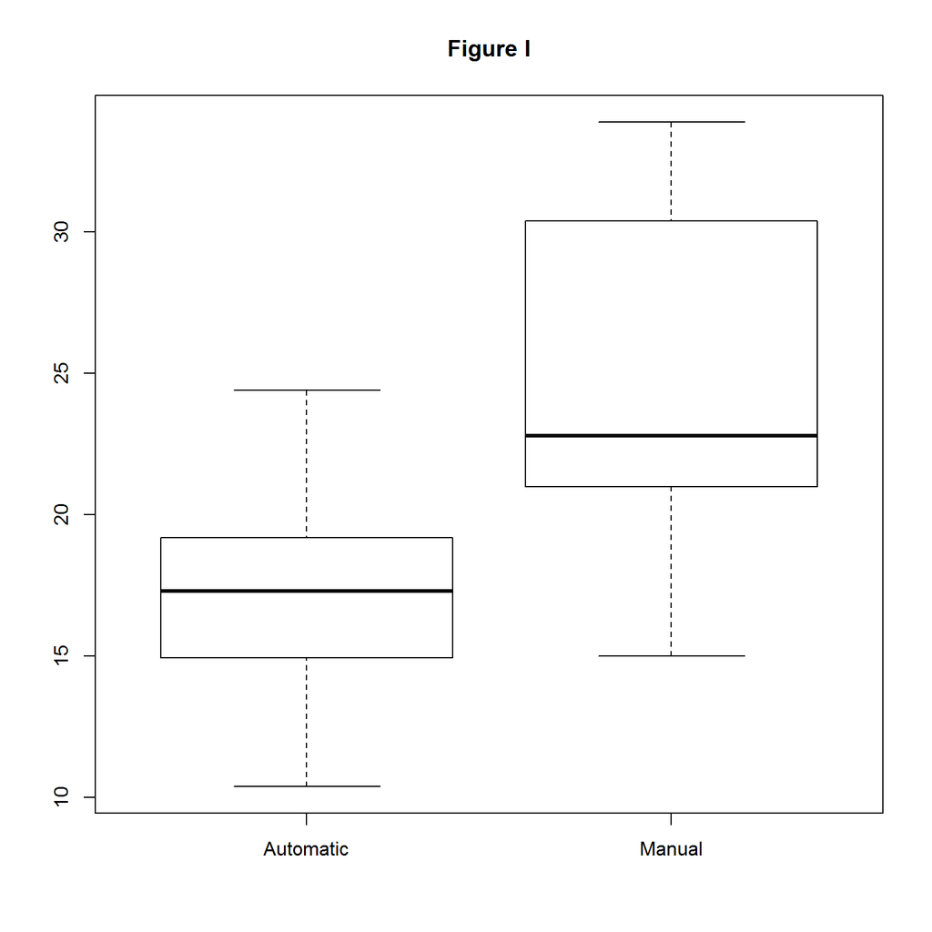

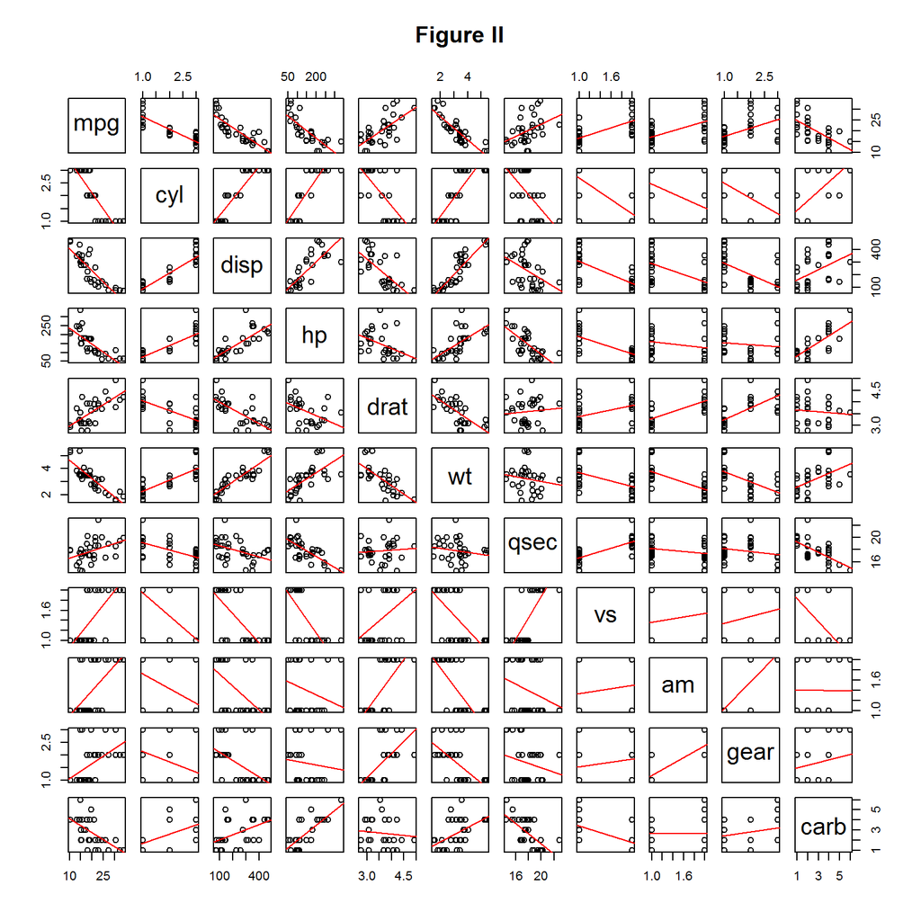

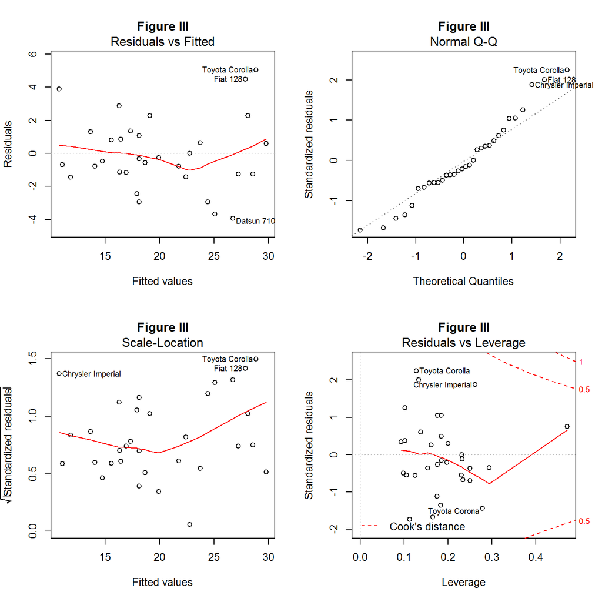